# Walkthrough 1

Matthew Biggs

#### The objectives of Project 1 include:

- Use existing data set in R
- Read data into R
- Produce a figure
- Use functions to filter and summarize your data sets
- Communicate results
- Submit your project on GitHub

Follows is an example project that meets these objectives.

#### Use existing data set in R

To see a [list of all the data sets](http://www.sthda.com/english/wiki/r-built-in-data-sets) that are available in your R distribution, type `data()` in your console.

This will bring up a long list of data sets with the name of the dataset on the left and a description on the right.

To learn more about any specific data set, such as the “precip” data set type `?precip`, which will yield a help page for that data set. Give it a try.

It says that it includes:

> The average amount of precipitation (rainfall) in inches for each of 70 United States (and Puerto Rico) cities.

The entire data set is made up of:

> A named vector of length 70.

And the original source for the data is:

> Statistical Abstracts of the United States, 1975.

For your project, pick any four datasets from that list. I’ll proceed with `precip` as an example.

#### Read data into R

Open RStudio and create a new R script.

Begin your R script by importing tidyverse and your chosen data set. For example:

```r
library(tidyverse)

data(precip)
```

#### Produce a figure

Use gglot2 to make a figure using your data set. `tibble` changes the data format to something more compatible with tidyverse tools. Check out [Chapter 10](http://r4ds.had.co.nz/tibbles.html) if you’re curious.

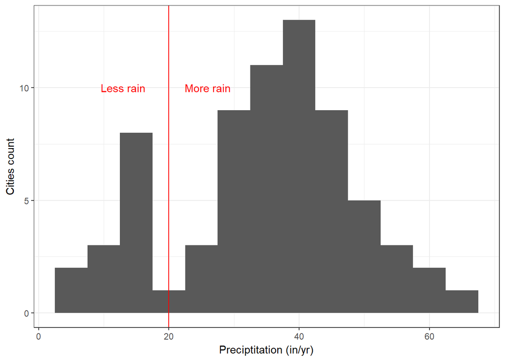

```r
tp = tibble(precip)
tp$names = names(precip)

ggplot(data = tp, mapping = aes(x=precip)) +
  geom_histogram(binwidth=5) +
  geom_vline(xintercept=20, color='red') +
  annotate('text', label='Less rain', x=13, y=10, color='red') +
  annotate('text', label='More rain', x=26, y=10, color='red') +
  theme_bw() +
  xlab('Preciptitation (in/yr)') +
  ylab('Cities count')
```

```r
more_rain_df = tp %>%
  filter(precip > 20)

less_rain_df = tp %>%
  filter(precip <= 20)

less_rain_df$names
```

```
##  [1] "Phoenix"        "Los Angeles"    "Sacramento"     "Denver"
##  [5] "Boise"          "Great Falls"    "Reno"           "Albuquerque"
##  [9] "Bismark"        "El Paso"        "Salt Lake City" "Spokane"
## [13] "Cheyenne"
```

#### Communicate results

“Communication” for project 1 will be a blog post. It should be an interpretation of your figures for an audience that is not necessarily familiar with your data set or the method of analysis.

The written part for each data set can look something like the following:

> This figure was derived from the “precip” data set in R, which is derived from “Statistical Abstracts of the United States, 1975”. It is a list of the average rainfall in 70 US cities. The average precipitation (reported in inches) is 34.89 inches. The distribution is bi-modal, with a distinct division between cities that receive less than or more than 20 inches of rain each year. Dividing the dataset at 20 in./year, the average of the higher rainfall group is 39.97 while that of the lower rainfall group is 12.61. The city that receives the most rain is Mobile while the city that receives the least is Phoenix.

> As a next step, it would be interesting to look at more than just the average rainfall, but actually see the distribution for each city, and see how the rainfall of recent years compares to the historical distribution.

#### Finish

Save your R script in your project folder, and then add, commit and push to GitHub.